# Assignment

[figure not shown]

```r
ggplot(Compare) + geom_line(aes(x = year, y =jail_pretrial_rate),color="blue")+
  theme_bw(base_line_size = 1) +
  labs(title= "Jail pretrial rate from 2010-2018 in Top10 jail admission county",y = "Rate",x="Year")
```

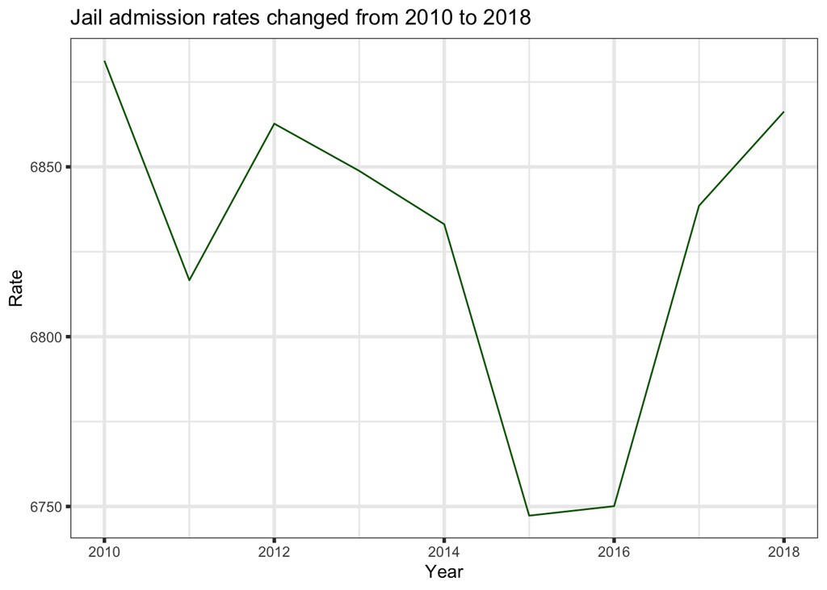

```r
ggplot(Compare) + geom_line(aes(x = year, y =jail_admission_rate),color="darkgreen")+
  theme_bw(base_line_size = 1) +
  labs(title= "Jail admission rates changed from 2010 to 2018",y = "Rate",x="Year")
```

Now, we study the jail population count by race geographically. Through this kind of analysis, we could explore how they are distributed geographically and whether there were geographically correlations.

Firstly, we would like to discover the change of white people jail population count between 2010 and 2018.

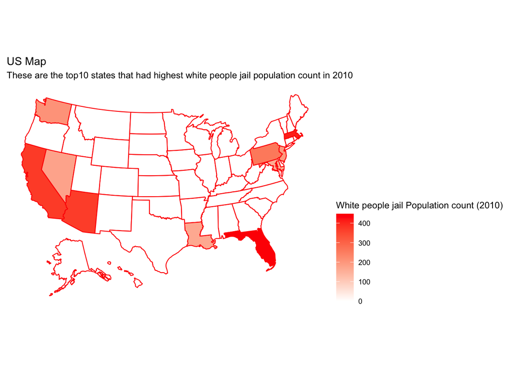

```r
library(usmap)
library(ggplot2)
#join dataset 2010
usdatawhite2010 <- new_data %>% filter(year==2010) %>% group_by(state,year) %>% summarise(
  white_jail_pop=mean(white_jail_pop,na.rm=T)
  ) %>% arrange(desc(white_jail_pop))
usdatawhite2010 <- usdatawhite2010[1:10,]
#join dataset 2018
usdatawhite2018 <- new_data %>% filter(year==2018) %>% group_by(state,year) %>% summarise(
  white_jail_pop=mean(white_jail_pop,na.rm=T)
  ) %>% arrange(desc(white_jail_pop))
usdatawhite2018 <- usdatawhite2018[1:10,]
#2010 map
usmapdata <-statepop
us2010 <- merge(usmapdata, usdatawhite2010, by.x = "abbr", by.y = "state",all.x=TRUE)
us2010[is.na(us2010)] <- 0
plot_usmap(
    data = us2010, values = "white_jail_pop", color = "red") +
  scale_fill_continuous(
    low = "white", high = "red", name = "White people jail Population count (2010)", label = scales::comma
  ) +
  labs(title = "US Map", subtitle = "These are the top10 states that had highest white people jail population count in 2010") +
  theme(legend.position = "right")
```

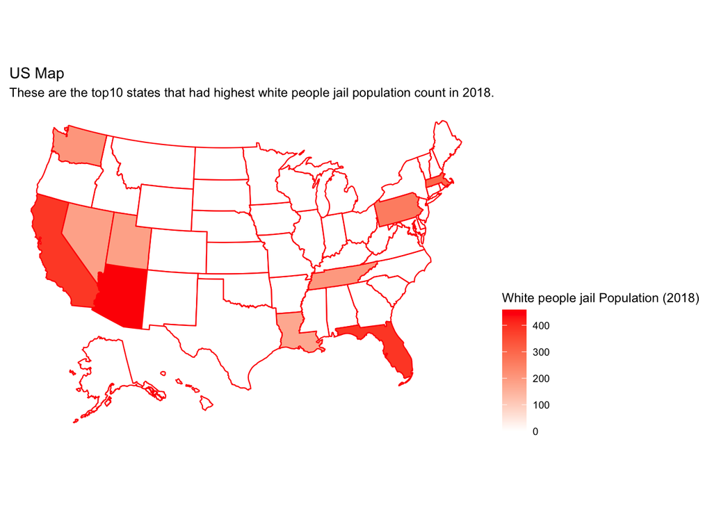

```r
us2018 <- merge(usmapdata, usdatawhite2018, by.x = "abbr", by.y = "state",all.x=TRUE)
us2018[is.na(us2018)] <- 0
plot_usmap(
    data = us2018, values = "white_jail_pop", color = "red") +
  scale_fill_continuous(
    low = "white", high = "red", name = "White people jail Population (2018)", label = scales::comma
  ) +
  labs(title = "US Map", subtitle = "These are the top10 states that had highest white people jail population count in 2018.") +
  theme(legend.position = "right")
```

As seen from above two figures,the white people jail population counts on national boundary were very high both in 2010 and 2018. In addition， there is a tendency to shift to the central part of U.S..

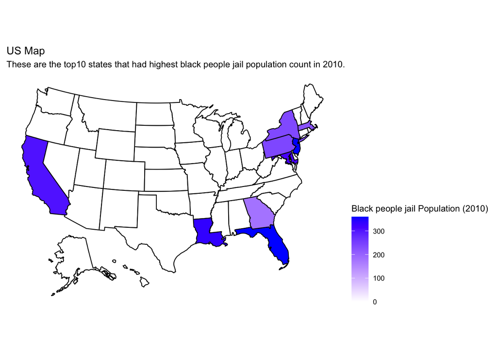

```r
usdatablack2018 <- new_data %>% filter(year==2010) %>% group_by(state,year) %>% summarise(
  black_jail_pop=mean(black_jail_pop,na.rm=T)
  ) %>% arrange(desc(black_jail_pop))

usdatablack2018 <- usdatablack2018[2:10,] #top is DC with 2786 we remove them
us2018 <- merge(usmapdata, usdatablack2018, by.x = "abbr", by.y = "state",all.x=TRUE)
us2018[is.na(us2018)] <- 0
plot_usmap(
    data = us2018, values = "black_jail_pop", color = "black") +
  scale_fill_continuous(
    low = "white", high = "blue", name = "Black people jail Population (2010)", label = scales::comma
  ) +
  labs(title = "US Map", subtitle = "These are the top10 states that had highest black people jail population count in 2010.") +
  theme(legend.position = "right")
```

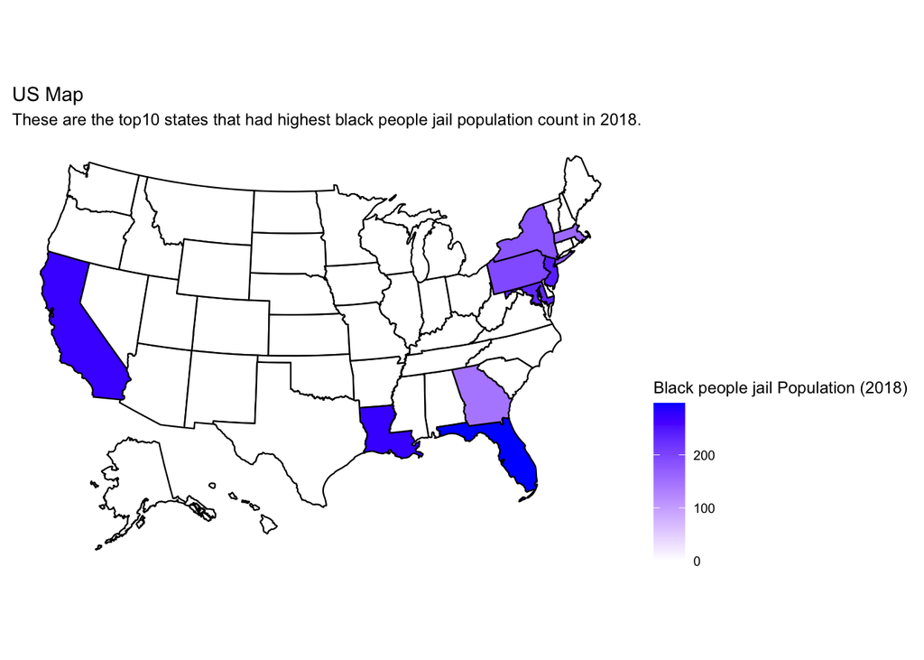

```r
usdatablack2018 <- new_data %>% filter(year==2018) %>% group_by(state,year) %>% summarise(
  black_jail_pop=mean(black_jail_pop,na.rm=T)
  ) %>% arrange(desc(black_jail_pop))

usdatablack2018 <- usdatablack2018[2:10,] #top is DC with 1774 we remove it
us2018 <- merge(usmapdata, usdatablack2018, by.x = "abbr", by.y = "state",all.x=TRUE)
us2018[is.na(us2018)] <- 0
plot_usmap(
    data = us2018, values = "black_jail_pop", color = "black") +
  scale_fill_continuous(
    low = "white", high = "blue", name = "Black people jail Population (2018)", label = scales::comma
  ) +
  labs(title = "US Map", subtitle = "These are the top10 states that had highest black people jail population count in 2018.") +
  theme(legend.position = "right")
```

As shown in above two figures, top 10 states that had highest black people jail population count remains unchanged. Especially in Washington DC, the count of black people jail population even reached around 2700, the situation eased in 2018 (still much higher with 1774). Compared to white people, they were more concentrated in the east part of U.S., therefore, the local authorities in east part of U.S. are supposed to pay more attention to racial equality of the incarceration.